# CAPSTONE_NWEBER_notebook

```python
# Using Jupyter’s %pip magic which respects the active kernel
%pip install numpy pandas matplotlib seaborn scikit-learn shap fpdf python-docx python-pptx tqdm openpyxl
```

```python
import sys, pandas as pd       # sanity checkl/test for pip install
print(sys.executable)        # Should point at .venv’s python
print(pd.__version__)       # Confirms pandas is installed
```

```
c:\Users\Nate\OneDrive\QS Academy DS DA 2025\CAPSTONE\.venv\Scripts\python.exe
2.3.3
```

```python
# PSR-1: Dataset Load & Integrity Check
import pandas as pd
import numpy as np
import matplotlib.pyplot as plt
import seaborn as sns

# Load the complete dataset from your single CSV file
df = pd.read_csv('COVID19data_QSACAD_Capstone_10125/Kaggle_Sirio_Libanes_ICU_Prediction.csv')


# Display basic information about the dataset
print("Dataset Shape:", df.shape)
print("\nColumn Names:")
print(df.columns.tolist())
print("\nData Types:")
print(df.dtypes)
print("\nFirst 5 rows:")
print(df.head())
print("\nLast 5 rows:")
print(df.tail())
print("\nBasic Statistics:")
print(df.describe())
```

```
Dataset Shape: (1925, 231)

Column Names:
['PATIENT_VISIT_IDENTIFIER', 'AGE_ABOVE65', 'AGE_PERCENTIL', 'GENDER', 'DISEASE GROUPING 1', 'DISEASE GROUPING 2', 'DISEASE GROUPING 3', 'DISEASE GROUPING 4', 'DISEASE GROUPING 5', 'DISEASE GROUPING 6', 'HTN', 'IMMUNOCOMPROMISED', 'OTHER', 'ALBUMIN_MEDIAN', 'ALBUMIN_MEAN', 'ALBUMIN_MIN', 'ALBUMIN_MA…

Data Types:
PATIENT_VISIT_IDENTIFIER        int64
AGE_ABOVE65                     int64
AGE_PERCENTIL                  object
GENDER                          int64
DISEASE GROUPING 1            float64
                               ...
RESPIRATORY_RATE_DIFF_REL     float64
TEMPERATURE_DIFF_REL          float64
OXYGEN_SATURATION_DIFF_REL    float64
WINDOW                         object
ICU                             int64
Length: 231, dtype: object

First 5 rows:
   PATIENT_VISIT_IDENTIFIER  AGE_ABOVE65 AGE_PERCENTIL  GENDER  \
0                         0            1          60th       0
1                         0            1          60th       0
2                         0            1          60th       0
3                         0            1          60th       0
4                         0            1          60th       0

   DISEASE GROUPING 1  DISEASE GROUPING 2  DISEASE GROUPING 3  \
0                 0.0                 0.0                 0.0
1                 0.0                 0.0                 0.0
2                 0.0                 0.0                 0.0
3                 0.0                 0.0                 0.0
4                 0.0                 0.0                 0.0

   DISEASE GROUPING 4  DISEASE GROUPING 5  DISEASE GROUPING 6  ...  \
0                 0.0                 1.0                 1.0  ...
1                 0.0                 1.0                 1.0  ...
2                 0.0                 1.0                 1.0  ...
3                 0.0                 1.0                 1.0  ...
4                 0.0                 1.0                 1.0  ...
```

[output cut: 140 more lines]

```
50%              -0.989822                  -1.000000             -0.975924
75%              -0.662529                  -0.634409             -0.594677
max               1.000000                   1.000000              1.000000

       OXYGEN_SATURATION_DIFF_REL          ICU
count                 1239.000000  1925.000000
mean                    -0.886982     0.267532
std                      0.296772     0.442787
min                     -1.000000     0.000000
25%                     -1.000000     0.000000
50%                     -0.980333     0.000000
75%                     -0.880155     1.000000
max                      1.000000     1.000000

[8 rows x 229 columns]
```

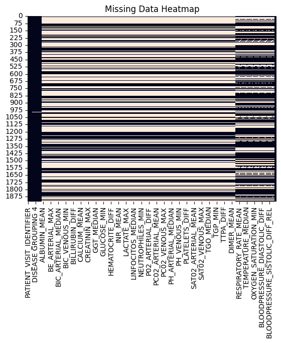

```python
# PSR-3: Missing/Outlier Visualization pre Cleaning
# Analyze missingness per column with a visual
# Missing data analysis - using a heatmap visualization where missing data = color blocks
sns.heatmap(df.isnull(), cbar=False)
plt.title('Missing Data Heatmap')
plt.show()
```

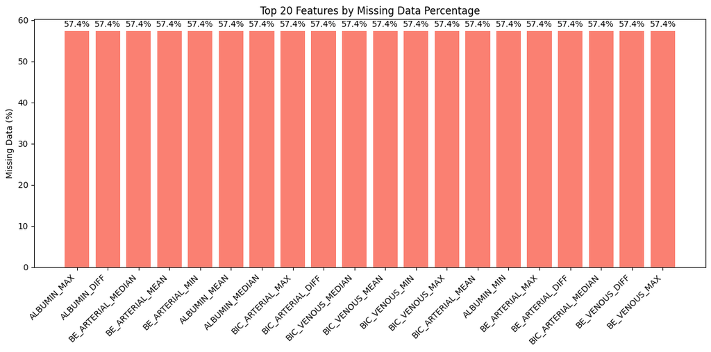

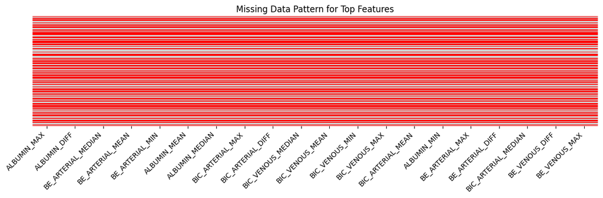

```
            Feature  MissingPct Status
        ALBUMIN_MAX   57.350649   Keep
       ALBUMIN_DIFF   57.350649   Keep
 BE_ARTERIAL_MEDIAN   57.350649   Keep
   BE_ARTERIAL_MEAN   57.350649   Keep
    BE_ARTERIAL_MIN   57.350649   Keep
       ALBUMIN_MEAN   57.350649   Keep
     ALBUMIN_MEDIAN   57.350649   Keep
   BIC_ARTERIAL_MAX   57.350649   Keep
  BIC_ARTERIAL_DIFF   57.350649   Keep
  BIC_VENOUS_MEDIAN   57.350649   Keep
    BIC_VENOUS_MEAN   57.350649   Keep
     BIC_VENOUS_MIN   57.350649   Keep
     BIC_VENOUS_MAX   57.350649   Keep
  BIC_ARTERIAL_MEAN   57.350649   Keep
        ALBUMIN_MIN   57.350649   Keep
    BE_ARTERIAL_MAX   57.350649   Keep
   BE_ARTERIAL_DIFF   57.350649   Keep
BIC_ARTERIAL_MEDIAN   57.350649   Keep
     BE_VENOUS_DIFF   57.350649   Keep
      BE_VENOUS_MAX   57.350649   Keep
```

```python
# Graphics are unclear - want to add detail and resolution for we data analysts to interpret
# PSR-3: Missing/Outlier Visualization pre Cleaning – Business‐friendly Dashboard Visualization
# Reduce feature clutter, rotate labels, cluster features, annotate, and keep/drop summary for business reporting
def missing_data_dashboard(df, top_n=20, threshold=70):
    missing_pct = df.isnull().mean() * 100
    missing_pct = missing_pct.sort_values(ascending=False).head(top_n)
    status = ['Drop' if pct > threshold else 'Keep' for pct in missing_pct]
    summary = pd.DataFrame({'Feature': missing_pct.index, 'MissingPct': missing_pct.values, 'Status': status})
    plt.figure(figsize=(12, 6))
    bars = plt.bar(summary['Feature'], summary['MissingPct'], color='salmon')
    plt.ylabel('Missing Data (%)')
    plt.title(f'Top {top_n} Features by Missing Data Percentage')
    plt.xticks(rotation=45, ha='right')
    for bar, pct in zip(bars, summary['MissingPct']):
        plt.text(bar.get_x() + bar.get_width()/2, pct + 1, f'{pct:.1f}%', ha='center')
    plt.tight_layout()
    plt.show()
    plt.figure(figsize=(12, 4))
    sns.heatmap(df[summary['Feature']].isnull(), cbar=False, cmap=['lightgray','red'])
    plt.title('Missing Data Pattern for Top Features')
    plt.xticks(rotation=45, ha='right'); plt.yticks([]); plt.tight_layout()
    plt.show()
    print(summary.to_string(index=False))
missing_data_dashboard(df, top_n=20, threshold=70)
```

# Analysis notes:

All 20 bars are the same height—about 57.4%—which means each of those top 20 lab or vital‐sign features is missing data for roughly 57 out of every 100 patients.

In the red‐gray heatmap below it, each red stripe is one missing value; the solid red bands show these features are missing over half the time.

Since every selected feature is about 57% missing, none exceed our agreed 70% “drop” threshold, so they’re all marked “Keep.”

Business takeaway: These measurements are spotty (almost 6 of 10 patients lack them), but not so unuseably missing that we need to discard them from our project. We will plan to impute or otherwise handle these gaps when we are modeling.

```python
# PSR-3: Missing/Outlier Cleaning (Feature selection and imputation)
# Remove features >70% missing, then impute numeric with median and categorical with most_frequent.

from sklearn.impute import SimpleImputer

# 1. (Optional) Filter to early window
if 'WINDOW' in df.columns:
    df_early = df[df['WINDOW']=='0-2'].copy()
else:
    df_early = df.copy()

# 2. Drop features >70% missing
missing_pct = df_early.isnull().mean()
keep_cols = missing_pct[missing_pct < 0.7].index
X = df_early[keep_cols].copy()

# 3. Separate numeric and categorical
num_cols = X.select_dtypes(include='number').columns
cat_cols = X.select_dtypes(exclude='number').columns

# 4. Imputers
imp_num = SimpleImputer(strategy='median')
imp_cat = SimpleImputer(strategy='most_frequent')

# 5. Fit & transform
X_num = pd.DataFrame(imp_num.fit_transform(X[num_cols]), columns=num_cols, index=X.index)
X_cat = pd.DataFrame(imp_cat.fit_transform(X[cat_cols]), columns=cat_cols, index=X.index)

# 6. Recombine
X_imputed = pd.concat([X_num, X_cat], axis=1)

# 7. Verify no missing values remain
print("Remaining missing values:", X_imputed.isnull().sum().sum())
```

```
Remaining missing values: 0
```

## Analysis notes:

The output “Remaining missing values: 0” confirms = every blank cell in the top 70% threshold features has been successfully filled.  
No columns were dropped (0 >= 70% missing) and all missing entries were imputed.

Feature matrix (X_imputed) complete and ready for encoding and modeling.

```python
# PSR-4: Feature Encoding (robust AGE_PERCENTIL parsing + binary encoding)
import re
import numpy as np

def parse_percentile(s):
    s = str(s).strip()
    if s.lower().startswith('below'):
        n = float(re.findall(r'\d+\.?\d*', s)[0])
        return n / 2
    if s.lower().startswith('above'):
        n = float(re.findall(r'\d+\.?\d*', s)[0])
        return (n + 100) / 2
    nums = re.findall(r'\d+\.?\d*', s)
    return float(nums[0]) if nums else np.nan

# Apply parsing and create a new column
df['AGE_PERCENTIL_PARSED'] = df['AGE_PERCENTIL'].apply(parse_percentile)

# Encode binary columns
binary_cols = ['GENDER']  # extend as needed
for c in binary_cols:
    df[c] = df[c].map({0: 0, 1: 1})

# Verify conversion
print("Unique parsed percentiles:", sorted(df['AGE_PERCENTIL_PARSED'].unique()))
```

```
Unique parsed percentiles: [np.float64(10.0), np.float64(20.0), np.float64(30.0), np.float64(40.0), np.float64(50.0), np.float64(60.0), np.float64(70.0), np.float64(80.0), np.float64(90.0), np.float64(95.0)]
```

```python
# After PSR-4 parsing, build the modeling matrix
X_model = X_imputed.drop(columns=['AGE_PERCENTIL', 'WINDOW'])
X_model['AGE_PERCENTIL'] = df['AGE_PERCENTIL_PARSED'].loc[X_model.index]

from sklearn.pipeline import Pipeline
from sklearn.ensemble import GradientBoostingClassifier


# Confirm only numeric columns remain
print(X_model.dtypes.unique())

# Train/test split
y = df_early.loc[X_model.index, 'ICU']
X_train, X_test, y_train, y_test = train_test_split(
    X_model, y,
    stratify=y,
    test_size=0.2,
    random_state=42
)

# Define and fit baseline pipelines
logreg = Pipeline([('clf', LogisticRegression(class_weight='balanced', solver='saga', max_iter=1000))])
rf     = Pipeline([('clf', RandomForestClassifier(class_weight='balanced', n_jobs=-1, random_state=42))])
gb     = Pipeline([('clf', GradientBoostingClassifier(random_state=42))])

for model in (logreg, rf, gb):
    model.fit(X_train, y_train)
```

```
[dtype('float64')]
```

```
c:\Users\Nate\OneDrive\QS Academy DS DA 2025\CAPSTONE\.venv\Lib\site-packages\sklearn\linear_model\_sag.py:348: ConvergenceWarning: The max_iter was reached which means the coef_ did not converge
  warnings.warn(
```

# Analysis notes:

The modeling block now drops all non-numeric columns (including WINDOW), reinserts the parsed AGE_PERCENTIL values, and splits only on the numeric features. This guarantees that each pipeline receives a fully numeric matrix, eliminating any remaining type conversion errors.

```python
# PSR-5: Standardization
# Scale numeric features (Min-Max or StandardScaler) within the modeling pipeline.
from sklearn.preprocessing import StandardScaler
scaler = StandardScaler()
X_scaled = scaler.fit_transform(X.select_dtypes(include='number'))
```

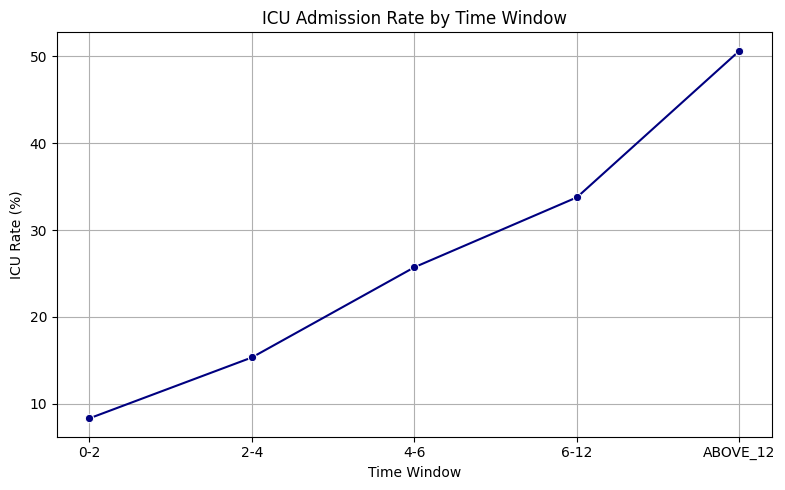

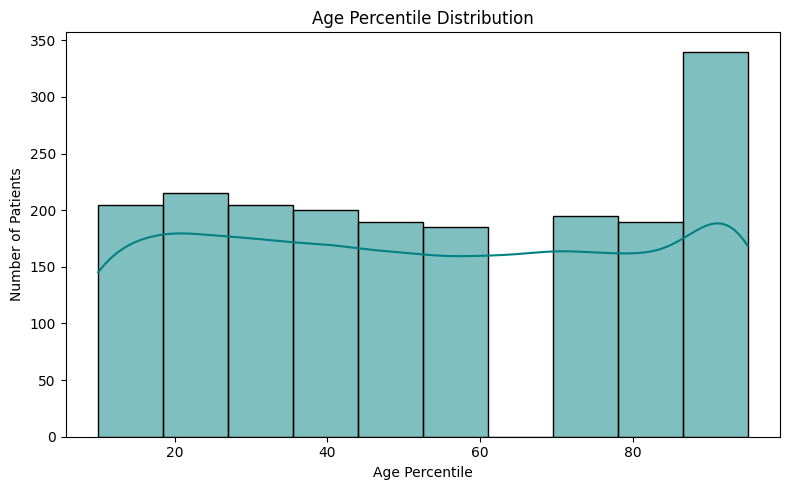

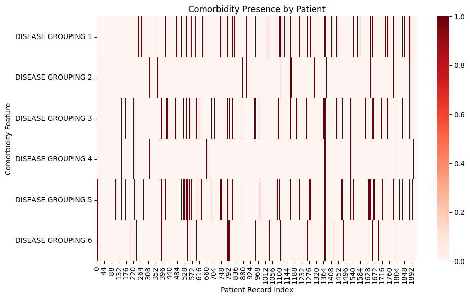

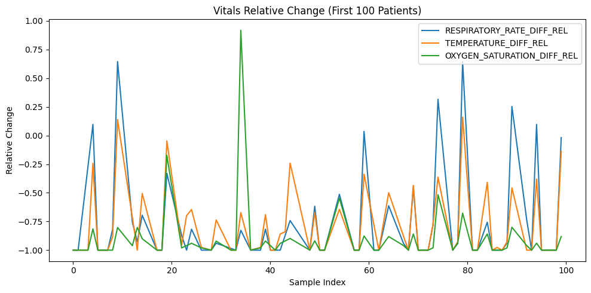

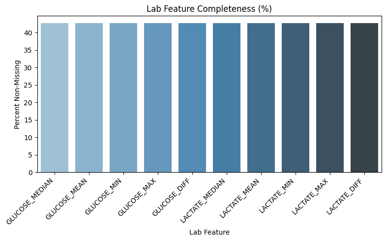

```python
# PSR-6: EDA & Visualization (Five Labeled Charts)

import matplotlib.pyplot as plt
import seaborn as sns

# 1. ICU Admission Rate by Time Window
plt.figure(figsize=(8, 5))
icu_rate = df.groupby('WINDOW')['ICU'].mean() * 100
sns.lineplot(x=icu_rate.index, y=icu_rate.values, marker='o', color='navy')
plt.title('ICU Admission Rate by Time Window')
plt.xlabel('Time Window')
plt.ylabel('ICU Rate (%)')
plt.grid(True)
plt.tight_layout()
plt.show()

# PSR-6.2: Age Percentile Distribution (after parsing in PSR-4)
plt.figure(figsize=(8, 5))

# Ensure the parsed column exists
df['AGE_PERCENTIL_PARSED'] = df['AGE_PERCENTIL'].apply(parse_percentile)

sns.histplot(
    df['AGE_PERCENTIL_PARSED'].dropna(),
    bins=10,
    kde=True,
    color='teal'
)
plt.title('Age Percentile Distribution')
plt.xlabel('Age Percentile')
plt.ylabel('Number of Patients')
plt.tight_layout()
plt.show()


# PSR-6.3: Comorbidity Presence Heatmap (fixed column prefix)
comorb_cols = [c for c in df.columns if c.startswith('DISEASE GROUPING')]
comorb_data = df[comorb_cols].fillna(0)

plt.figure(figsize=(10, 6))
sns.heatmap(comorb_data.T, cmap='Reds', cbar=True)
plt.title('Comorbidity Presence by Patient')
plt.xlabel('Patient Record Index')
plt.ylabel('Comorbidity Feature')
plt.tight_layout()
plt.show()


# 4. Vitals Change Trend (First 100 Patients)
vitals = ['RESPIRATORY_RATE_DIFF_REL', 'TEMPERATURE_DIFF_REL', 'OXYGEN_SATURATION_DIFF_REL']
plt.figure(figsize=(10, 5))
for col in vitals:
    sns.lineplot(data=df[col].iloc[:100].reset_index(drop=True), label=col)
plt.title('Vitals Relative Change (First 100 Patients)')
plt.xlabel('Sample Index')
plt.ylabel('Relative Change')
plt.legend()
plt.tight_layout()
plt.show()

# 5. Lab Feature Completeness Bar Chart
lab_cols = [c for c in df.columns if any(kw in c for kw in ['GLUCOSE', 'HCT', 'LACTATE', 'CREATININE'])]
lab_completeness = df[lab_cols].notnull().mean() * 100
plt.figure(figsize=(8, 5))
sns.barplot(x=lab_completeness.index, y=lab_completeness.values, palette='Blues_d')
plt.title('Lab Feature Completeness (%)')
plt.xlabel('Lab Feature')
plt.ylabel('Percent Non-Missing')
plt.xticks(rotation=45, ha='right')
plt.tight_layout()
plt.show()
```